# 11 FY19 refresh

# Setup

```r
# Document parameters
# Look for # <UPDATE> tags
threads <- 3 # <UPDATE>
# Packages
library(tidyverse)
library(reshape2)
library(gridExtra)
library(splines)
library(lubridate)
library(wranglR)
library(Boruta)
library(foreach)
library(doParallel)
library(mgcv)
# Functions adapted from previous analysis steps
source('code/functions.R')
# Visualization functions adapted fron previous analysis steps
source('code/functions_viz.R')
# Set number of available CPU cores
registerDoParallel(threads)
```

```r
# Load current data
# Import data
train_fy <- 2017 # <UPDATE>
source('code/generate-pit-data.R')
# Run data generation functions
# Ensure that the file pointed to has the correct train_fy (2 FY ago)
full.data <- generate_pit_data(
  filepath = 'data/2019-10-04 point-in-time data.xlsx' # <UPDATE>
  , sheetname = 'Select point_in_time_model_2019' # <UPDATE>
)
```

```r
# Updated dataset
modeling.data <- full.data %>%
  generate_additional_predictors()
```

# Updated models

I’m reusing the model parameters from FY18-19; see [06 KSM model tuning](https://phively.github.io/ksm-models/pg-cultivation-score-fy18/06%20KSM%20model%20tuning.nb.html#probability_model_tuning)

```r
# Model parameters
giving <- 3
dollars <- 2
engagement <- 3
recordyr <- 5
```

Updating the GAM (unconditional probability).

```r
gam_final <- gam(
  rv.gave ~
  PROGRAM_GROUP +
  PREF_ADDR_TYPE_CODE +
  HOUSEHOLD_CONTINENT +
  BUS_IS_EMPLOYED +
  HAS_HOME_ADDR +
  HAS_HOME_PHONE +
  s(YEARS_SINCE_FIRST_GIFT, k = giving) +
  s(GIVING_FIRST_YEAR_CASH_AMT, k = giving) +
  s(GIVING_MAX_PLEDGE_AMT, k = giving) +
  s(GIVING_CASH_TOTAL, k = giving) +
  s(GIVING_PLEDGE_TOTAL, k = giving) +
  s(GIVING_CRU_TOTAL, k = giving) +
  s(GIFTS_ALLOCS_SUPPORTED, k = giving) +
  s(GIFTS_FYS_SUPPORTED, k = giving) +
  s(GIFTS_CASH, k = giving) +
  s(GIFTS_PLEDGES, k = giving) +
  s(CASH_PFY1, k = dollars) +
  s(CASH_PFY2, k = dollars) +
  s(CASH_PFY3, k = dollars) +
  s(CASH_PFY4, k = dollars) +
  s(CASH_PFY5, k = dollars) +
  CRU_GIVING_SEGMENT +
  s(EVALUATION_LOWER_BOUND, k = dollars) +
  s(UOR_LOWER_BOUND, k = dollars) +
  s(MONTHS_ASSIGNED, k = engagement) +
  s(COMMITTEE_NU_DISTINCT, k = engagement) +
  s(COMMITTEE_NU_YEARS, k = engagement) +
  s(COMMITTEE_KSM_DISTINCT, k = engagement) +
  s(EVENTS_PREV_3_FY, k = engagement) +
  s(EVENTS_CFY, k = engagement) +
  s(EVENTS_PFY1, k = engagement) +
  s(ATHLETICS_TICKET_YEARS, k = engagement) +
  s(YEARS_SINCE_ATHLETICS_TICKETS, k = engagement) +
  s(RECORD_YR, k = recordyr) +
  s(YEARS_SINCE_MAX_CASH_YR, k = giving) +
  GIVING_MAX_CASH_MO +
  KSM_PROSPECT +
  s(VISITORS_5FY, k = engagement) +
  LOYAL_5_PCT_CASH +
  UPGRADE3_CASH +
  VELOCITY3_LIN_CASH +
  SPOUSE_ALUM
  , data = modeling.data
  , family = 'binomial'
  , control = list(nthreads = threads)
)
```

```
basis dimension, k, increased to minimum possible
basis dimension, k, increased to minimum possible
basis dimension, k, increased to minimum possible
basis dimension, k, increased to minimum possible
basis dimension, k, increased to minimum possible
basis dimension, k, increased to minimum possible
basis dimension, k, increased to minimum possible
```

Updating the LM (conditional expectation).

```r
lm_final <- lm(
  rv.amt ~
  COMMITTEE_KSM_LDR +
  ns(CRU_PFY1, df = 2) +
  ns(CRU_PFY2, df = 1) +
  ns(CRU_PFY3, df = 1) +
  ns(CRU_PFY4, df = 1) +
  ns(CRU_PFY5, df = 1) +
  ns(EVALUATION_LOWER_BOUND, df = 1) +
  GIFT_CLUB_NU_LDR_YRS +
  ns(GIFTS_ALLOCS_SUPPORTED, df = 1) +
  ns(GIFTS_OUTRIGHTS_PAYMENTS, df = 1) +
  ns(GIVING_CRU_TOTAL, df = 1) +
  ns(GIVING_MAX_CASH_YR, df = 1) +
  ns(GIVING_MAX_PLEDGE_AMT, df = 1) +
  ns(GIVING_MAX_PLEDGE_FY, df = 1) +
  HOUSEHOLD_CONTINENT +
  KSM_GOS_FLAG +
  LOYAL_5_PCT_ANY +
  ns(NGC_PFY1, df = 2) +
  ns(NGC_PFY2, df = 1) +
  ns(NGC_PFY3, df = 1) +
  ns(NGC_PFY4, df = 1) +
  ns(NGC_PFY5, df = 1) +
  PREF_ADDR_TYPE_CODE +
  PROGRAM_GROUP +
  ns(RECORD_YR, df = 5) +
  ns(UOR_LOWER_BOUND, df = 1) +
  UPGRADE3_CASH +
  ns(VELOCITY3_LIN_NGC, df = 7) +
  ns(VISITS_5FY, df = 1)
  , data = modeling.data %>% filter(rv.gave == TRUE)
)
```

# Generate new predictions

```r
# Load current data
# Parameters
train_fy <- 2019 # <UPDATE>
filepath <- 'data/2019-10-08 point-in-time fy19 future data.xlsx' # <UPDATE>
sheetname <- 'Select point_in_time_model_19fu' # <UPDATE>

# Run data generation functions
# Ensure that the file pointed to has the correct train_fy (current FY)
new.full.data <- generate_pit_data(filepath, sheetname)
new.modeling.data <- new.full.data %>% generate_additional_predictors(future.data = TRUE)
```

```r
preds_prb <- predict(gam_final, newdata = new.modeling.data, type = 'response') %>% as.numeric()
preds_amt <- predict(lm_final, newdata = new.modeling.data, type = 'response')
```

# New prediction diagnostics

```r
data.frame(
  data = 'insample'
  , prediction = gam_final$fitted.values
) %>% rbind(
  data.frame(
    data = 'outsample'
    , prediction = preds_prb
  )
) %>%
  ggplot(aes(x = prediction, fill = data)) +
  geom_histogram(bins = 20) +
  facet_wrap(. ~ data) +
  labs(title = 'Probability model fitted values')
```

[output not shown]

Looks fine.

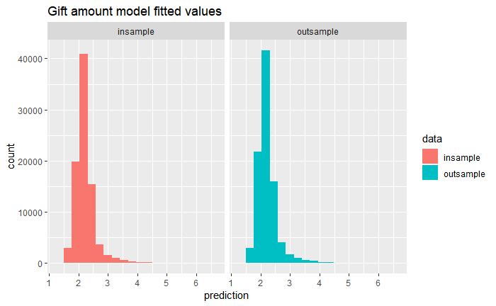

```r
data.frame(
  data = 'insample'
  , prediction = predict(lm_final, newdata = modeling.data)
) %>% rbind(
  data.frame(
    data = 'outsample'
    , prediction = preds_amt
  )
) %>%
  ggplot(aes(x = prediction, fill = data)) +
  geom_histogram(bins = 20) +
  facet_wrap(. ~ data) +
  labs(title = 'Gift amount model fitted values')
```

Looks fine.

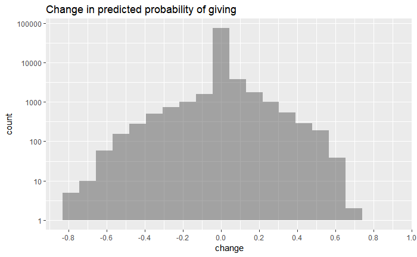

```r
data.frame(
  id = modeling.data$ID_NUMBER %>% as.numeric()
  , p_insample = gam_final$fitted.values
) %>% inner_join(
  data.frame(
    id = new.modeling.data$ID_NUMBER %>% as.numeric()
    , p_outsample = preds_prb
  )
  , by = c('id')
) %>% mutate(
  change = p_insample - p_outsample
) %>%
  ggplot(aes(x = change)) +
  geom_histogram(bins = 20, alpha = .5) +
  scale_x_continuous(breaks = seq(-1, 1, by = .2)) +
  scale_y_log10(breaks = 10^(0:6), labels = format(10^(0:6), scientific = FALSE)) +
  labs(title = 'Change in predicted probability of giving')
```

Some pretty large swings but very few over $\pm .5$ (log scale) and the near-symmetry is reassuring.

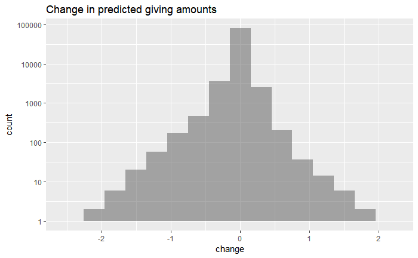

```r
data.frame(
  id = modeling.data$ID_NUMBER %>% as.numeric()
  , p_insample = predict(lm_final, newdata = modeling.data)
) %>% inner_join(
  data.frame(
    id = new.modeling.data$ID_NUMBER %>% as.numeric()
    , p_outsample = preds_amt
  )
  , by = c('id')
) %>% mutate(
  change = p_insample - p_outsample
) %>%
  ggplot(aes(x = change)) +
  geom_histogram(bins = 16, alpha = .5) +
  scale_y_log10(breaks = 10^(0:6), labels = format(10^(0:6), scientific = FALSE)) +
  labs(title = 'Change in predicted giving amounts')
```

Looks fine, and the near-symmetry is reassuring.

# Previous model comparison

```r
fy18_prb <- predict(gam_final_18, newdata = new.modeling.data, type = 'response') %>% as.numeric()
fy18_amt <- predict(lm_final_18, newdata = new.modeling.data, type = 'response')
```

```r
# FY18 data max EV score (PR)
idx <- which(new.modeling.data$ID_NUMBER == '0000372980')
data.frame(
  p18 = fy18_prb[idx]
  , p19 = preds_prb[idx]
  , g18 = fy18_amt[idx]
  , g19 = preds_amt[idx]
) %>% mutate(
  ev18 = p18 * g18
  , ev19 = p19 * g19
)
```

| p18 | p19 | g18 | g19 | ev18 | ev19 |
| --- | --- | --- | --- | --- | --- |
| 0.9472969 | 0.2547114 | 7.209173 | 6.570111 | 6.829227 | 1.673482 |

Interestingly, the amount models are pretty close but the probabilities are very different.

## LM comparison

```r
coef18_lm <- summary(lm_final_18)$coef %>% data.frame() %>%
  select(Estimate18 = Estimate, SE18 = Std..Error, Pr.t18 = Pr...t..)
coef19_lm <- summary(lm_final)$coef %>% data.frame() %>%
  select(Estimate19 = Estimate, SE19 = Std..Error, Pr.t19 = Pr...t..)
cbind(
  coef18_lm
  , coef19_lm
) %>% mutate(
  varname = rownames(coef18_lm)
  , delta = Estimate19 - Estimate18
  , delta_pct = {delta / abs(Estimate18)} %>% scales::percent()
) %>% select(
  varname
  , Estimate18
  , Estimate19
  , delta
  , delta_pct
  , SE18
  , SE19
  , Pr.t18
  , Pr.t19
) %>% mutate_if(
  is.numeric, signif, 3
)
```

| varname | Estimate18 | Estimate19 | delta | delta_pct | SE18 | SE19 | Pr.t18 | Pr.t19 |
| --- | --- | --- | --- | --- | --- | --- | --- | --- |
| (Intercept) | 1.3900 | 0.84300 | -0.54700 | -40% | 0.1900 | 0.1950 | 3.15e-13 | 1.48e-05 |
| COMMITTEE_KSM_LDR | 0.0125 | 0.01360 | 0.00107 | 10% | 0.0136 | 0.0131 | 3.59e-01 | 2.99e-01 |
| ns(CRU_PFY1, df = 2)1 | 0.2550 | 0.37600 | 0.12200 | 50% | 0.0846 | 0.0888 | 2.60e-03 | 2.30e-05 |
| ns(CRU_PFY1, df = 2)2 | 1.3200 | 1.48000 | 0.15800 | 10% | 0.1660 | 0.1820 | 2.15e-15 | 4.63e-16 |
| ns(CRU_PFY2, df = 1) | -0.0215 | 0.13500 | 0.15700 | 730% | 0.0923 | 0.0964 | 8.15e-01 | 1.60e-01 |
| ns(CRU_PFY3, df = 1) | 0.1110 | -0.08080 | -0.19200 | -170% | 0.0847 | 0.0925 | 1.91e-01 | 3.82e-01 |
| ns(CRU_PFY4, df = 1) | -0.1340 | -0.11300 | 0.02080 | 20% | 0.0690 | 0.0761 | 5.19e-02 | 1.36e-01 |
| ns(CRU_PFY5, df = 1) | 0.0268 | -0.06350 | -0.09030 | -340% | 0.0791 | 0.0738 | 7.35e-01 | 3.89e-01 |
| ns(EVALUATION_LOWER_BOUND, df = 1) | 0.2900 | 0.19500 | -0.09440 | -30% | 0.0328 | 0.0307 | 1.21e-18 | 2.14e-10 |
| GIFT_CLUB_NU_LDR_YRS1+ | 0.1940 | 0.19700 | 0.00223 | 0% | 0.0181 | 0.0174 | 8.12e-27 | 2.32e-29 |

[output cut: 44 more lines]

## GAM comparison

```r
coef18_gam <- summary(gam_final_18)
coef19_gam <- summary(gam_final)
data.frame(
  names = coef18_gam$p.coeff %>% names()
  , coef18 = coef18_gam$p.coeff
  , coef19 = coef19_gam$p.coeff
) %>% mutate(
  delta = coef19 - coef18
  , delta_pct = {delta / abs(coef18)} %>% scales::percent()
  , t18 = coef18_gam$p.t
  , t19 = coef19_gam$p.t
)
```

| names | coef18 | coef19 | delta | delta_pct | t18 | t19 |
| --- | --- | --- | --- | --- | --- | --- |
| (Intercept) | -3.225165204 | -3.67410065 | -0.448935447 | -10% | -13.52896006 | -15.2762425 |
| PROGRAM_GROUPNONE | -1.253577097 | -1.32976719 | -0.076190095 | -10% | -11.26977466 | -11.5018229 |
| PROGRAM_GROUPEMP | -0.199774404 | 0.05009762 | 0.249872026 | 130% | -3.55371759 | 0.8907796 |
| PROGRAM_GROUPEXECED | -2.983593387 | -3.23007410 | -0.246480713 | -10% | -8.64279625 | -8.8641958 |
| PROGRAM_GROUPNONGRD | -1.729556067 | -2.31018258 | -0.580626513 | -30% | -3.26272986 | -3.1706702 |
| PROGRAM_GROUPPHD | -0.049827616 | -0.46636019 | -0.416532572 | -840% | -0.24706615 | -2.0189815 |
| PROGRAM_GROUPTMP | -0.293655471 | -0.34471636 | -0.051060886 | -20% | -6.15828373 | -7.0619892 |
| PREF_ADDR_TYPE_CODEALT | -0.429833232 | -0.01632823 | 0.413505002 | 100% | -2.60311708 | -0.1097385 |
| PREF_ADDR_TYPE_CODEBUS | -0.012258920 | -0.14015241 | -0.127893489 | -1,040% | -0.17468636 | -1.8779326 |
| HOUSEHOLD_CONTINENT | -2.275064368 | -2.57172663 | -0.296662259 | -10% | -15.27718306 | -16.0708015 |

[output cut: 33 more lines]

There are some very wide swings in how certain variables, such as upgrade amounts, are treated. I’m thinking these should be handled differently in the future when I refit a new model.

# Diagnostics

```r
# Diagnostic data
error_compare_18 <- data.frame(
  giving = log10plus1(modeling.data$rv.amt, inverse = TRUE)
  , log.giving = modeling.data$rv.amt
  , gave = modeling.data$rv.gave
  , est.giving = predict(lm_final_18, newdata = modeling.data, type = 'response')
  , est.gave = predict(gam_final_18, newdata = modeling.data, type = 'response') %>% as.numeric()
) %>% mutate(
  ev = est.giving * est.gave
  , error = log.giving - ev
  , log.giving.bin = trunc(log.giving)
  , pred.giving.bin = trunc(est.giving)
  , ev.bin = trunc(ev)
)
```

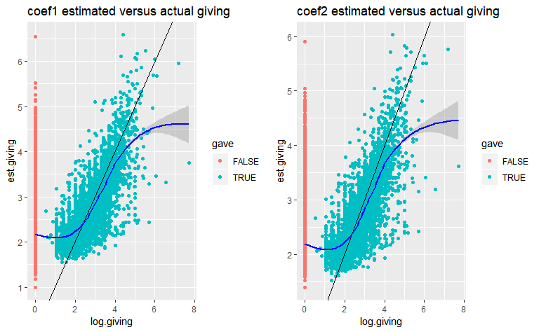

```r
grid.arrange(
error_compare_18 %>%
  ggplot(aes(x = log.giving, y = est.giving, color = gave)) +
  geom_point() +
  geom_abline(aes(slope = 1, intercept = 0)) +
  geom_smooth(method = 'gam', formula = y ~ s(x, bs = 'cs'), color = 'blue') +
  labs(title = 'coef1 estimated versus actual giving')
, error_compare %>%
  ggplot(aes(x = log.giving, y = est.giving, color = gave)) +
  geom_point() +
  geom_abline(aes(slope = 1, intercept = 0)) +
  geom_smooth(method = 'gam', formula = y ~ s(x, bs = 'cs'), color = 'blue') +
  labs(title = 'coef2 estimated versus actual giving')
, ncol = 2
)
```

```r
data.frame(
  model = c('coef1', 'coef2')
  , mse = c(
    calc_mse(y = error_compare$log.giving, yhat = error_compare$est.giving)
    , calc_mse(y = error_compare_18$log.giving, yhat = error_compare_18$est.giving)
  )
)
```

| model | mse |
| --- | --- |
| coef1 | 4.454823 |
| coef2 | 4.422375 |

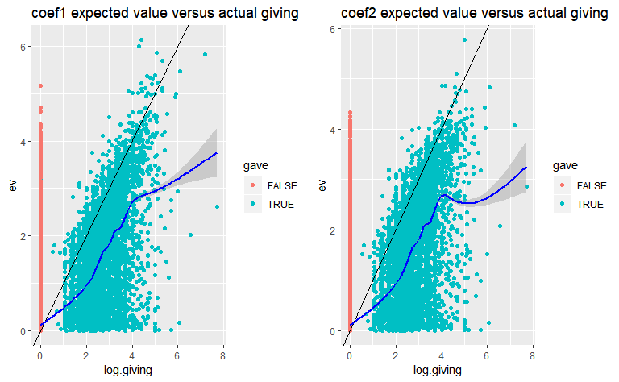

```r
grid.arrange(
error_compare_18 %>%
  ggplot(aes(x = log.giving, y = ev, color = gave)) +
  geom_point() +
  geom_abline(aes(slope = 1, intercept = 0)) +
  geom_smooth(method = 'gam', formula = y ~ s(x, bs = 'cs'), color = 'blue') +
  labs(title = 'coef1 expected value versus actual giving')
, error_compare %>%
  ggplot(aes(x = log.giving, y = ev, color = gave)) +
  geom_point() +
  geom_abline(aes(slope = 1, intercept = 0)) +
  geom_smooth(method = 'gam', formula = y ~ s(x, bs = 'cs'), color = 'blue') +
  labs(title = 'coef2 expected value versus actual giving')
, ncol = 2
)
```

```r
data.frame(
  model = c('coef1', 'coef2')
  , mse = c(
    calc_mse(y = error_compare_18$log.giving, yhat = error_compare_18$ev)
    , calc_mse(y = error_compare$log.giving, yhat = error_compare$ev)
  )
)
```

| model | mse |
| --- | --- |
| coef1 | 0.2862015 |
| coef2 | 0.2835996 |

The coef2 model trend line is non-monotonic which is pretty odd.

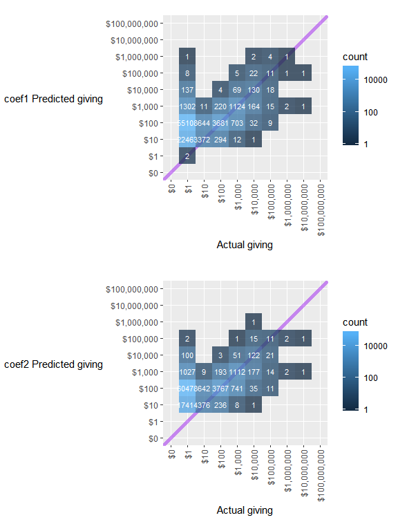

```r
error_bin <- error_compare %>%
  group_by(log.giving.bin, pred.giving.bin) %>%
  summarise(n = length(gave), g = sum(gave))
error_bin_18 <- error_compare_18 %>%
  group_by(log.giving.bin, pred.giving.bin) %>%
  summarise(n = length(gave), g = sum(gave))
mingift <- -1
maxgift <- 8
grid.arrange(
error_bin_18 %>%
  ggplot(aes(x = log.giving.bin, y = pred.giving.bin, fill = n)) +
  geom_abline(color = 'purple', size = 2, alpha = .5) +
  geom_tile(alpha = .75) +
  geom_text(aes(label = n), color = 'white', size = 3) +
  scale_fill_gradient(name = 'count', trans = 'log10') +
  scale_x_continuous(breaks = mingift:maxgift, minor_breaks = NULL
                     , labels = 10^(mingift:maxgift) %>% scales::dollar(), limits = c(mingift, maxgift)) +
  scale_y_continuous(breaks = mingift:maxgift, minor_breaks = NULL
                     , labels = 10^(mingift:maxgift) %>% scales::dollar(), limits = c(mingift, maxgift)) +
  coord_equal() +
  theme(axis.text.x = element_text(angle = 90, hjust = 1, vjust = .5), axis.title.y = element_text(angle = 0, vjust = .5)) +
  labs(x = 'Actual giving', y = 'coef1 Predicted giving')
, error_bin %>%
  ggplot(aes(x = log.giving.bin, y = pred.giving.bin, fill = n)) +
  geom_abline(color = 'purple', size = 2, alpha = .5) +
  geom_tile(alpha = .75) +
  geom_text(aes(label = n), color = 'white', size = 3) +
  scale_fill_gradient(name = 'count', trans = 'log10') +
  scale_x_continuous(breaks = mingift:maxgift, minor_breaks = NULL
                     , labels = 10^(mingift:maxgift) %>% scales::dollar(), limits = c(mingift, maxgift)) +
  scale_y_continuous(breaks = mingift:maxgift, minor_breaks = NULL
                     , labels = 10^(mingift:maxgift) %>% scales::dollar(), limits = c(mingift, maxgift)) +
  coord_equal() +
  theme(axis.text.x = element_text(angle = 90, hjust = 1, vjust = .5), axis.title.y = element_text(angle = 0, vjust = .5)) +
  labs(x = 'Actual giving', y = 'coef2 Predicted giving')
)
```

**coef1 model**

- Total giving during the out-of-sample time period was $97,525,891.
- Those predicted to give at least $1,000 gave $92,902,087, or 95.3% of the total.
- A total of 3253 donors were predicted to give at the $1,000 level and 1570 actually did, for a hit rate of 48.3%.
- Average giving in this group is $28,558.90 per person.
- This method elimintates 83321 entities, who gave a total of $4,623,804, or an average of $55.49 per person.

**coef2 model**

- Total giving during the out-of-sample time period was $97,525,891.
- Those predicted to give at least $1,000 gave $92,481,811, or 94.8% of the total.
- A total of 2865 donors were predicted to give at the $1,000 level and 1531 actually did, for a hit rate of 53.4%.
- Average giving in this group is $32,279.86 per person.
- This method elimintates 83709 entities, who gave a total of $5,044,080, or an average of $60.26 per person.

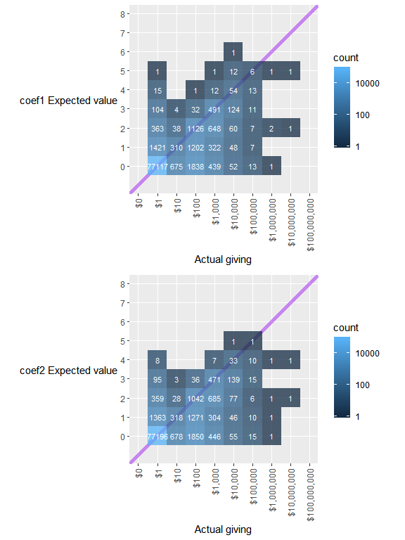

```r
ev_bin_18 <- error_compare_18 %>%
  group_by(log.giving.bin, ev.bin) %>%
  summarise(n = length(gave), g = sum(gave))
ev_bin <- error_compare %>%
  group_by(log.giving.bin, ev.bin) %>%
  summarise(n = length(gave), g = sum(gave))
mingift <- -1
maxgift <- 8
grid.arrange(
ev_bin_18 %>%
  ggplot(aes(x = log.giving.bin, y = ev.bin, fill = n)) +
  geom_abline(color = 'purple', size = 2, alpha = .5) +
  geom_tile(alpha = .75) +
  geom_text(aes(label = n), color = 'white', size = 3) +
  scale_fill_gradient(name = 'count', trans = 'log10') +
  scale_x_continuous(breaks = mingift:maxgift, minor_breaks = NULL
                     , labels = 10^(mingift:maxgift) %>% scales::dollar(), limits = c(mingift, maxgift)) +
  scale_y_continuous(breaks = 0:maxgift, minor_breaks = NULL, limits = c(mingift, maxgift)) +
  coord_equal() +
  theme(axis.text.x = element_text(angle = 90, hjust = 1, vjust = .5), axis.title.y = element_text(angle = 0, vjust = .5)) +
  labs(x = 'Actual giving', y = 'coef1 Expected value')
, ev_bin %>%
  ggplot(aes(x = log.giving.bin, y = ev.bin, fill = n)) +
  geom_abline(color = 'purple', size = 2, alpha = .5) +
  geom_tile(alpha = .75) +
  geom_text(aes(label = n), color = 'white', size = 3) +
  scale_fill_gradient(name = 'count', trans = 'log10') +
  scale_x_continuous(breaks = mingift:maxgift, minor_breaks = NULL
                     , labels = 10^(mingift:maxgift) %>% scales::dollar(), limits = c(mingift, maxgift)) +
  scale_y_continuous(breaks = 0:maxgift, minor_breaks = NULL, limits = c(mingift, maxgift)) +
  coord_equal() +
  theme(axis.text.x = element_text(angle = 90, hjust = 1, vjust = .5), axis.title.y = element_text(angle = 0, vjust = .5)) +
  labs(x = 'Actual giving', y = 'coef2 Expected value')
)
```

**coef1**

- Total giving during the out-of-sample time period was again $97,525,891.
- Entities with a score of 1 or higher (6439 total) gave $91,907,963, or 94.2% of the total.
- Of these 6439 entities, 4539 were donors (70.5%), and 1822 gave at least $1,000 (28.3%).
- Average giving in this group is $14,273.64 per person.
- This method elimintates 80135 entities, who gave a total of $5,617,928, or an average of $70.11 per person.

**coef2**

- Total giving during the out-of-sample time period was again $97,525,891.
- Entities with a score of 1 or higher (6333 total) gave $91,059,932, or 93.4% of the total.
- Of these 6333 entities, 4512 were donors (71.2%), and 1810 gave at least $1,000 (28.6%).
- Average giving in this group is $14,378.64 per person.
- This method elimintates 80241 entities, who gave a total of $6,465,959, or an average of $80.58 per person.

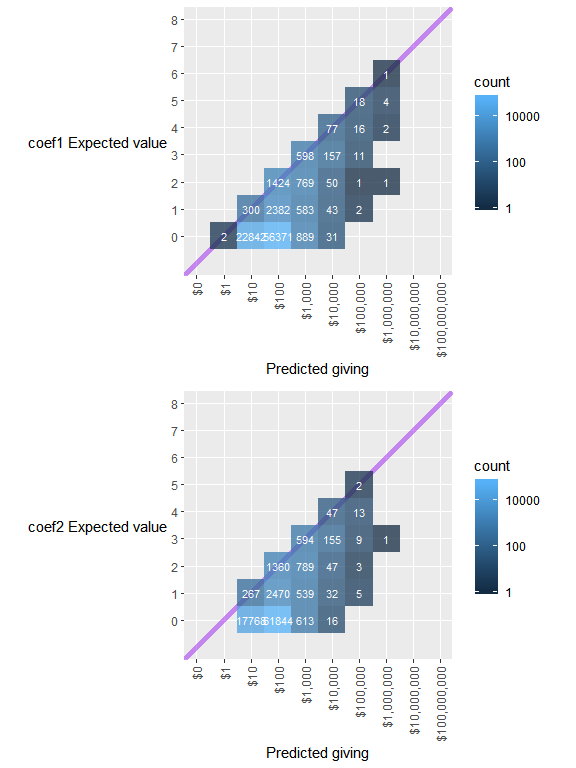

```r
both_bin_2018 <- error_compare_18%>%
  group_by(pred.giving.bin, ev.bin) %>%
  summarise(n = length(gave), g = sum(gave))
both_bin <- error_compare %>%
  group_by(pred.giving.bin, ev.bin) %>%
  summarise(n = length(gave), g = sum(gave))
mingift <- -1
maxgift <- 8
grid.arrange(
both_bin_2018 %>%
  ggplot(aes(x = pred.giving.bin, y = ev.bin, fill = n)) +
  geom_abline(color = 'purple', size = 2, alpha = .5) +
  geom_tile(alpha = .75) +
  geom_text(aes(label = n), color = 'white', size = 3) +
  scale_fill_gradient(name = 'count', trans = 'log10') +
  scale_x_continuous(breaks = mingift:maxgift, minor_breaks = NULL
                     , labels = 10^(mingift:maxgift) %>% scales::dollar(), limits = c(mingift, maxgift)) +
  scale_y_continuous(breaks = 0:maxgift, minor_breaks = NULL, limits = c(mingift, maxgift)) +
  coord_equal() +
  theme(axis.text.x = element_text(angle = 90, hjust = 1, vjust = .5), axis.title.y = element_text(angle = 0, vjust = .5)) +
  labs(x = 'Predicted giving', y = 'coef1 Expected value')
, both_bin %>%
  ggplot(aes(x = pred.giving.bin, y = ev.bin, fill = n)) +
  geom_abline(color = 'purple', size = 2, alpha = .5) +
  geom_tile(alpha = .75) +
  geom_text(aes(label = n), color = 'white', size = 3) +
  scale_fill_gradient(name = 'count', trans = 'log10') +
  scale_x_continuous(breaks = mingift:maxgift, minor_breaks = NULL
                     , labels = 10^(mingift:maxgift) %>% scales::dollar(), limits = c(mingift, maxgift)) +
  scale_y_continuous(breaks = 0:maxgift, minor_breaks = NULL, limits = c(mingift, maxgift)) +
  coord_equal() +
  theme(axis.text.x = element_text(angle = 90, hjust = 1, vjust = .5), axis.title.y = element_text(angle = 0, vjust = .5)) +
  labs(x = 'Predicted giving', y = 'coef2 Expected value')
)
```

**coef1**

- Of the 920 individuals with a relatively high predicted giving amount ($1,000) but a 0 expected value score, only 151 were actually donors (16.4%), giving a total of $2,510,973.

**coef2**

- Of the 629 individuals with a relatively high predicted giving amount ($1,000) but a 0 expected value score, only 130 were actually donors (20.7%), giving a total of $3,031,271.

This compares favorably with [last year’s results](https://phively.github.io/ksm-models/pg-cultivation-score-fy18/06%20KSM%20model%20tuning.nb.html#combined_model).

# Score correlations

```r
# EOFY18 scores
fy18_ev_export <- read.csv(file = 'data/2019-01-09 export.csv')
yoy_comparison <- fy18_ev_export %>%
  select(ID_NUMBER, ev) %>%
  inner_join(
    output_data %>% select(ID_NUMBER, ev.coef1) %>% mutate(ID_NUMBER = as.numeric(ID_NUMBER))
    , by = 'ID_NUMBER'
  )
```

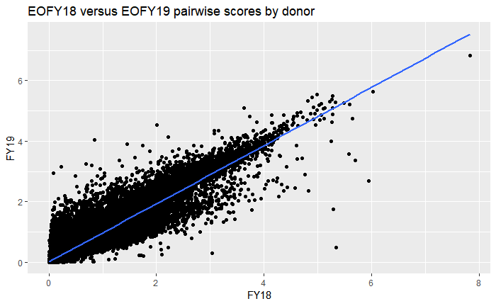

```r
# EOFY18 versus EOFY19 pairwise scores by donor
yoy_comparison %>%
  ggplot(aes(x = ev, y = ev.coef1)) +
  geom_point() +
  geom_smooth(method = 'lm') +
  labs(title = 'EOFY18 versus EOFY19 pairwise scores by donor', x = 'FY18', y = 'FY19')
```

```r
NA
```

```r
lm(ev.coef1 ~ ev, data = yoy_comparison) %>% summary()
```

```
Call:
lm(formula = ev.coef1 ~ ev, data = yoy_comparison)

Residuals:
    Min      1Q  Median      3Q     Max
-4.6484 -0.0093 -0.0085 -0.0064  3.2312

Coefficients:
             Estimate Std. Error t value Pr(>|t|)
(Intercept) 0.0085774  0.0008164   10.51   <2e-16 ***
ev          0.9610744  0.0011695  821.78   <2e-16 ***
---
Signif. codes:  0 ‘***’ 0.001 ‘**’ 0.01 ‘*’ 0.05 ‘.’ 0.1 ‘ ’ 1

Residual standard error: 0.1997 on 71722 degrees of freedom
Multiple R-squared:  0.904, Adjusted R-squared:  0.904
F-statistic: 6.753e+05 on 1 and 71722 DF,  p-value: < 2.2e-16
```

That’s a very high correlation between PFY and CFY scores, as expected.

# Save results

```r
# Merged data frame
output_data <- data.frame(
  est.giving.coef1 = fy18_amt
  , est.p.coef1 = fy18_prb
) %>% mutate(
  ev.coef1 = est.giving.coef1 * est.p.coef1
  , est.giving.bin.coef1 = trunc(est.giving.coef1)
  , est.p.bin.coef1 = trunc(est.p.coef1 * 10)
  , ev.bin.coef1 = trunc(ev.coef1)
  , est.giving.coef2 = preds_amt
  , est.p.coef2 = preds_prb
  , ev.coef2 = est.giving.coef2 * est.p.coef2
  , est.giving.bin.coef2 = trunc(est.giving.coef2)
  , est.p.bin.coef2 = trunc(est.p.coef2 * 10)
  , ev.bin.coef2 = trunc(ev.coef2)
) %>% cbind(
  new.modeling.data
)
```

```r
# Master data file
output_data %>% write.csv(
  file = 'data/2019-10-17 predictions.csv'
  , row.names = FALSE
)
```

```r
# IDs and scores only
full.data %>% filter(
  # Exclude deceased
  RECORD_STATUS_CODE != 'D'
) %>% select(
  HOUSEHOLD_ID
  , ID_NUMBER
) %>% mutate(
  HOUSEHOLD_ID = HOUSEHOLD_ID %>% as.numeric()
) %>% left_join(
  output_data %>% mutate(
      HOUSEHOLD_ID = ID_NUMBER %>% as.numeric()
    ) %>%
    select(
      HOUSEHOLD_ID
      , est.giving.coef1
      , est.p.coef1
      , ev.coef1
      , est.giving.bin.coef1
      , est.p.bin.coef1
      , ev.bin.coef1
    )
  , by = c('HOUSEHOLD_ID')
) %>% write.csv(
  file = 'data/2019-10-17 export.csv'
  , row.names = FALSE
)
```